# Exploratory Data Analysis of Factors Affecting Median Household Income in Seattle

### By Kevin Chen

This analysis uses Seattle Census data to explore the factors which may affect the household income. The analysis aims to quantify the correlation and present the geographical distribution of these variables on map.

## Problem

The median household income in Seattle is unequally distributed in communities. The initial guess is that race and education would be the factors affecting household income.

### 1. Univariate analysis

- Get demographic data from community report

The community data come from seattle government open data portal, which contain census results of 53 communities in seattle in 2013.

```r
community=read.csv('https://raw.githubusercontent.com/chjy0205/PROJECT/master/Community%20Reporting%20Areas.csv',stringsAsFactors = F)
```

- Verify data types

```r
str(community)
```

```
## 'data.frame':    53 obs. of  26 variables:
##  $ 锘縊BJECTID                                                                   : int  44 24 21 8 9 36 1 20 50 41 ...
##  $ CRA.ID                                                                        : num  1.4 1.1 10.4 3.5 13.1 9.1 6.2 11.3 8.3 5.3 ...
##  $ Community.Reporting.Area.Name                                                 : chr  "Alki" "Arbor Heights" "Adams" "Mid-Beacon Hill" ...
##  $ Area.Acres                                                                    : num  898 786 493 841 176 ...
##  $ Total.population                                                              : int  11502 6268 7425 9526 8455 13725 20952 13546 12859 17911 ...
##  $ Percent.of.Population.under.18.years                                          : num  16.3 20.7 8.2 18.4 1.6 14.6 4.7 4.1 18.8 14.1 ...
##  $ Median.Age..years.                                                            : num  44.3 41.2 32.9 39 40.2 45.5 31.8 32.8 40.3 33.4 ...
##  $ Black.or.African.American.alone..Not.Hispanic.or.Latino.                      : int  291 30 116 1137 837 1244 1498 510 1027 3007 ...
##  $ Percent.Black.or.African.American.alone..Not.Hispanic.or.Latino.              : num  2.5 0.5 1.6 11.9 9.9 9.1 7.1 3.8 8 16.8 ...
##  $ Person.of.Color                                                               : int  1836 1291 1532 7678 2890 4014 6114 4600 4165 6820 ...
##  $ Percent.of.Population.of.Color                                                : num  16 20.6 20.6 80.6 34.2 29.2 29.2 34 32.4 38.1 ...
##  $ High.school.graduate..includes.equivalency.                                   : int  897 886 792 1120 650 1767 1313 817 1371 1459 ...
##  $ Bachelor.degree                                                               : int  3514 1424 2502 1923 2594 3386 6220 4461 2597 4870 ...
##  $ Percent.High.school.graduate.or.higher                                        : num  97.9 97.2 96 75 95.8 93.5 97.3 96 92.6 94.1 ...
##  $ Percent.Bachelor.degree.or.higher                                             : num  59.6 49 60.3 33.2 61.5 47.8 59.1 62.1 52.8 59.8 ...
##  $ Population.5.years.and.over                                                   : int  10862 5843 7080 8757 8359 13148 20358 13224 12185 17025 ...
##  $ Speak.language.other.than.English                                             : int  1561 652 1459 5352 1666 2897 3929 2557 2978 2959 ...
##  $ Percent.of.Population.that.speaks.language.other.than.English                 : num  14.4 11.2 20.6 61.1 19.9 22 19.3 19.3 24.4 17.4 ...
##  $ Speak.English.less.than.very.well                                             : int  339 203 361 3174 473 1057 1119 643 1103 1043 ...
##  $ Percent.Speak.English.less.than.very.well                                     : num  3.1 3.5 5.1 36.2 5.7 8 5.5 4.9 9.1 6.1 ...
##  $ Median.household.income..dollars.                                             : int  80275 90621 60625 73160 56664 68931 48182 62841 73032 67142 ...
##  $ Percentage.of.all.people.whose.income.in.the.past.12.months.is.below.poverty  : num  6.6 3.8 8 10.6 20.3 17.3 16.2 16.4 18.6 13.7 ...
##  $ Percentage.of.all.families.whose.income.in.the.past.12.months.is.below.poverty: num  3.4 1.2 2.1 4.6 8.1 11 9.8 8.8 11.5 6.7 ...
##  $ Total.population.for.whom.poverty.status.is.determined                        : int  11421 6254 7377 9446 8307 13303 20911 13340 12738 17725 ...
##  $ Population.200..below.poverty                                                 : int  1589 691 1374 2737 2618 4177 6832 3587 3873 5373 ...
##  $ Percent.of.Population.200..below.poverty                                      : num  13.9 11 18.6 29 31.5 31.4 32.7 26.9 30.4 30.3 ...
```

- Centrality

It is noticeable that there is a huge gap between minimum median household income and maximum one. My following analysis explores the potential causes of this situation.

```r
summary(community$Median.household.income..dollars.)
```

```
##    Min. 1st Qu.  Median    Mean 3rd Qu.    Max.
##   20812   53182   69468   69601   81842  113457
```

- Dispersion

```r
library(moments)
sd(community$Median.household.income..dollars.,na.rm= T)
```

```
## [1] 20854.14
```

```r
sd(community$Median.household.income..dollars.,na.rm =T)/mean(community$Median.household.income..dollars.,na.rm =T)
```

```
## [1] 0.2996258
```

- Skewness

The distribution of median household income is close to normal distribution.

```r
skewness(community$Median.household.income..dollars.,na.rm=T)
```

```
## [1] -0.01773624
```

- Kurtosis

```r
kurtosis(community$Median.household.income..dollars.,na.rm = T)
```

```
## [1] 2.721353
```

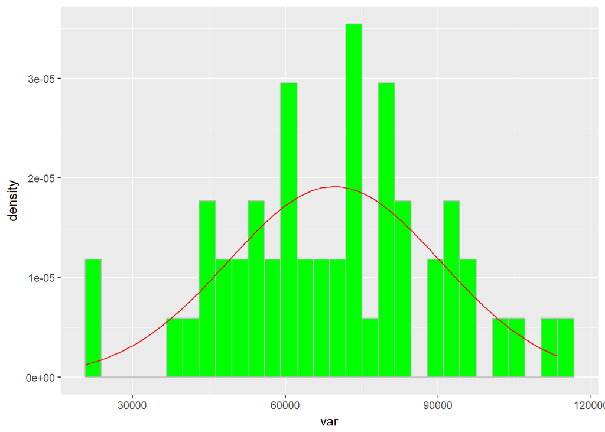

```r
data=community[is.finite(community$Median.household.income..dollars.),]
var=data$Median.household.income..dollars.
mnVar=mean(var,na.rm = T)
sdVar=sd(var,na.rm = T)

library(ggplot2)

base=ggplot(data, aes(x=var))
hist = base + geom_histogram(fill="green",
                             color='grey',
                          aes(y=..density..))
histAndNormal = hist + stat_function(fun=dnorm,
                                     color="red",
                                     args=list(mean=mnVar,sd=sdVar))

histAndNormal
```

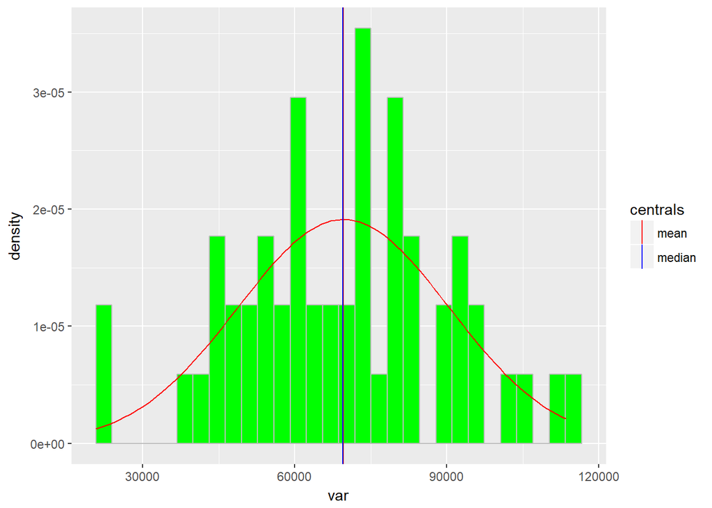

```r
mdVar=median(var)
histAndNormal + geom_vline(aes(xintercept = mnVar,colour="mean"),
                           show.legend  = TRUE) +
                geom_vline(aes(xintercept = mdVar,colour="median"),
                           show.legend  = TRUE) +
                scale_color_manual(name = "centrals",
                                   values = c(median = "blue", mean = "red"))
```

### 2. Clustering

I try to cluster the communities based on their median income, degree and percentage of people of color. We could see three main groups in clustering which indicates that race and education level do have correlations with household income.

```r
length(community$Community.Reporting.Area.Name)==length(unique(community$Community.Reporting.Area.Name))
```

```
## [1] TRUE
```

```r
row.names(community)=community$Community.Reporting.Area.Name

str(community[,c(11,15,21)])
```

```
## 'data.frame':    53 obs. of  3 variables:
##  $ Percent.of.Population.of.Color   : num  16 20.6 20.6 80.6 34.2 29.2 29.2 34 32.4 38.1 ...
##  $ Percent.Bachelor.degree.or.higher: num  59.6 49 60.3 33.2 61.5 47.8 59.1 62.1 52.8 59.8 ...
##  $ Median.household.income..dollars.: int  80275 90621 60625 73160 56664 68931 48182 62841 73032 67142 ...
```

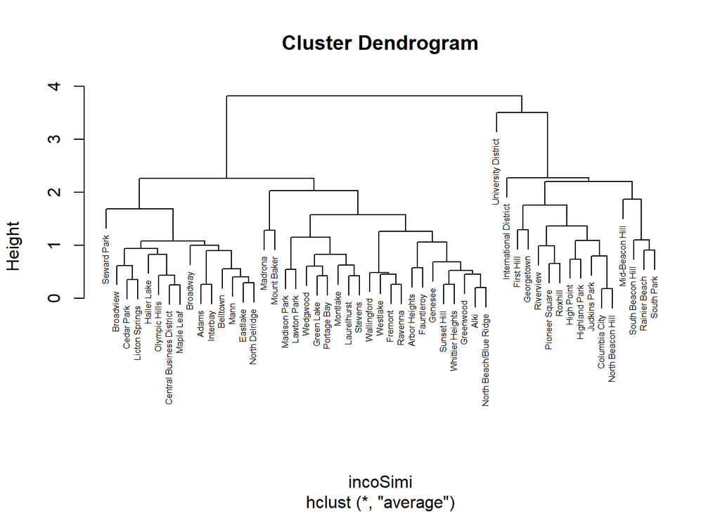

```r
library(cluster)
incoSimi=daisy(community[,c(11,15,21)],metric = "euclidean",
               stand=TRUE)
incoClus=hclust(incoSimi,method = 'average')
plot(incoClus,cex=0.5)
```

* Use 3 groups

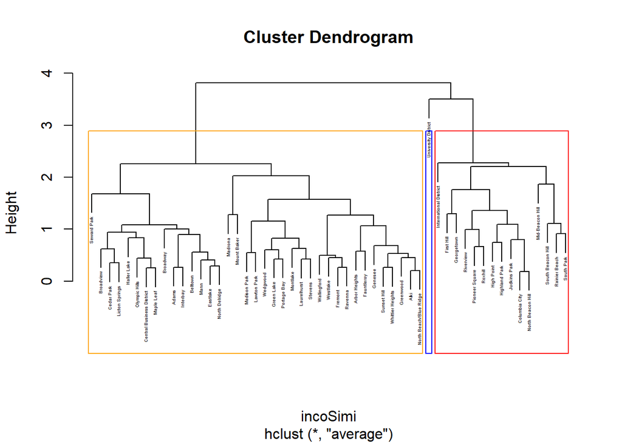

```r
plot(incoClus,cex=0.3)
rect.hclust(incoClus, k = 3,border = c('orange','blue','red'))
```

- Use 4 groups

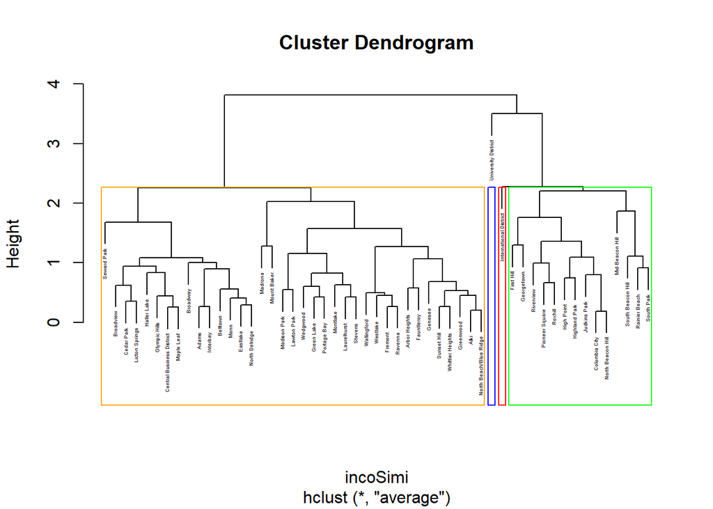

```r
plot(incoClus,cex=0.3)
rect.hclust(incoClus, k = 4,border = c('orange','blue','red','green'))
```

- Find out units of analysis which are difficult to cluster

```r
length(community$Community.Reporting.Area.Name)=length(unique(community$Community.Reporting.Area.Name))

row.names(community)=community$Community.Reporting.Area.Name

str(community[,c(11,15,21)])
```

```
## 'data.frame':    53 obs. of  3 variables:
##  $ Percent.of.Population.of.Color   : num  16 20.6 20.6 80.6 34.2 29.2 29.2 34 32.4 38.1 ...
##  $ Percent.Bachelor.degree.or.higher: num  59.6 49 60.3 33.2 61.5 47.8 59.1 62.1 52.8 59.8 ...
##  $ Median.household.income..dollars.: int  80275 90621 60625 73160 56664 68931 48182 62841 73032 67142 ...
```

```r
library(cluster)
incoSimi=daisy(community[,c(11,15,21)],metric="euclidean",
               stand=TRUE)

demsil4=silhouette(cutree(incoClus, k = 4), incoSimi)
clust4solution=data.frame(matrix(demsil4,ncol = 3,dimnames =dimnames(demsil4)))
row.names(clust4solution)=community$Community.Reporting.Area.Name
(bad4=clust4solution[clust4solution$sil_width<0,])
```

|  | cluster | neighbor | sil_width |
| --- | --- | --- | --- |
| Broadway | 1 | 4 | -0.19467194 |
| First Hill | 2 | 4 | -0.16787763 |
| Haller Lake | 1 | 2 | -0.02425535 |
| South Beacon Hill | 2 | 3 | -0.14296574 |
| South Park | 2 | 3 | -0.13987769 |

```r
demsil3=silhouette(cutree(incoClus, k = 3), incoSimi)
clust3solution=data.frame(matrix(demsil4,ncol = 3,dimnames =dimnames(demsil3)))
row.names(clust4solution)=community$Community.Reporting.Area.Name
(bad3=clust4solution[clust4solution$sil_width<0,])
```

|  | cluster | neighbor | sil_width |
| --- | --- | --- | --- |
| Broadway | 1 | 4 | -0.19467194 |
| First Hill | 2 | 4 | -0.16787763 |
| Haller Lake | 1 | 2 | -0.02425535 |
| South Beacon Hill | 2 | 3 | -0.14296574 |
| South Park | 2 | 3 | -0.13987769 |

```r
intersect(row.names(bad4),row.names(bad3))
```

```
## [1] "Broadway"          "First Hill"        "Haller Lake"
## [4] "South Beacon Hill" "South Park"
```

### 3. Linear Regression

This part tests the correlation among median income(Y variable), degree and population of color(X variables). Regression also serves as the main part of data analysis.

- Check the data

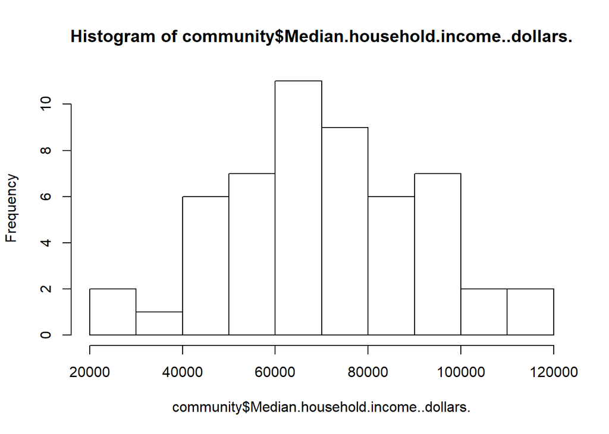

```r
hist(community$Median.household.income..dollars.)
```

- Verify that each variable in X has a linear relationship with Y.

```r
explanans=names(community)[c(11,15)]
for (x in explanans){
    par=cbind(community[,x],community$Median.household.income..dollars.)
    p=cor.test(community[,x],community$Median.household.income..dollars.)
    print(paste("Pearson:",p$estimate," - Is significative?",p$p.value<0.05))
}
```

```
## [1] "Pearson: -0.616941406130821  - Is significative? TRUE"
## [1] "Pearson: 0.663963914331116  - Is significative? TRUE"
```

- Check the correlation between each pair of X variables.

```r
cor(community[explanans])
```

```
##                                   Percent.of.Population.of.Color
## Percent.of.Population.of.Color                         1.0000000
## Percent.Bachelor.degree.or.higher                     -0.8182718
##                                   Percent.Bachelor.degree.or.higher
## Percent.of.Population.of.Color                           -0.8182718
## Percent.Bachelor.degree.or.higher                         1.0000000
```

- Set the row names with the community names.

```r
row.names(community)=community$Community.Reporting.Area.Name
```

- Request a linear regression model and check the detailed result.

```r
LinRegINCOME=lm(community$Median.household.income..dollars.~ Percent.of.Population.of.Color + Percent.Bachelor.degree.or.higher, data = community)

summary(LinRegINCOME)
```

```
##
## Call:
## lm(formula = community$Median.household.income..dollars. ~ Percent.of.Population.of.Color +
##     Percent.Bachelor.degree.or.higher, data = community)
##
## Residuals:
##    Min     1Q Median     3Q    Max
## -53389  -8753   1327   6689  32939
##
## Coefficients:
##                                   Estimate Std. Error t value Pr(>|t|)
## (Intercept)                        44080.0    18734.3   2.353   0.0226 *
## Percent.of.Population.of.Color      -232.0      188.7  -1.230   0.2246
## Percent.Bachelor.degree.or.higher    617.5      232.4   2.657   0.0105 *
## ---
## Signif. codes:  0 '***' 0.001 '**' 0.01 '*' 0.05 '.' 0.1 ' ' 1
##
## Residual standard error: 15670 on 50 degrees of freedom
## Multiple R-squared:  0.4573, Adjusted R-squared:  0.4355
## F-statistic: 21.06 on 2 and 50 DF,  p-value: 2.316e-07
```

- Regression of income and percent population of color

```r
LinRegINCOME1=lm(community$Median.household.income..dollars.~Percent.of.Population.of.Color, data=community)
summary(LinRegINCOME1)
```

```
##
## Call:
## lm(formula = community$Median.household.income..dollars. ~ Percent.of.Population.of.Color,
##     data = community)
##
## Residuals:
##    Min     1Q Median     3Q    Max
## -44025  -8385  -1769   9185  44752
##
## Coefficients:
##                                Estimate Std. Error t value Pr(>|t|)
## (Intercept)                     92455.8     4674.4  19.779  < 2e-16 ***
## Percent.of.Population.of.Color   -642.2      114.7  -5.598 8.68e-07 ***
## ---
## Signif. codes:  0 '***' 0.001 '**' 0.01 '*' 0.05 '.' 0.1 ' ' 1
##
## Residual standard error: 16570 on 51 degrees of freedom
## Multiple R-squared:  0.3806, Adjusted R-squared:  0.3685
## F-statistic: 31.34 on 1 and 51 DF,  p-value: 8.675e-07
```

This result is statistically significant which indicates that holding all other factors constant, one percent increase in percent of population of color is associated with $642.2 decrease in median household income.

- Regression of income and percent bachelor degree or higher

```r
LinRegINCOME2=lm(community$Median.household.income..dollars.~Percent.Bachelor.degree.or.higher, data=community)
summary(LinRegINCOME2)
```

```
##
## Call:
## lm(formula = community$Median.household.income..dollars. ~ Percent.Bachelor.degree.or.higher,
##     data = community)
##
## Residuals:
##    Min     1Q Median     3Q    Max
## -57174  -9516   1542   6642  28533
##
## Coefficients:
##                                   Estimate Std. Error t value Pr(>|t|)
## (Intercept)                        23035.0     7655.4   3.009  0.00407 **
## Percent.Bachelor.degree.or.higher    851.3      134.2   6.341 5.97e-08 ***
## ---
## Signif. codes:  0 '***' 0.001 '**' 0.01 '*' 0.05 '.' 0.1 ' ' 1
##
## Residual standard error: 15750 on 51 degrees of freedom
## Multiple R-squared:  0.4408, Adjusted R-squared:  0.4299
## F-statistic: 40.21 on 1 and 51 DF,  p-value: 5.971e-08
```

This result is statistically significant which indicates that holding all other factors constant, one percent increase of population with bachelor degree or higher is associated with $851.3 increase in median household income.

- Regression of degree and population of color

```r
LinRegINCOME3=lm(community$Percent.Bachelor.degree.or.higher~Percent.of.Population.of.Color, data=community)
summary(LinRegINCOME3)
```

```
##
## Call:
## lm(formula = community$Percent.Bachelor.degree.or.higher ~ Percent.of.Population.of.Color,
##     data = community)
##
## Residuals:
##     Min      1Q  Median      3Q     Max
## -23.824  -6.915   1.202   6.767  19.131
##
## Coefficients:
##                                Estimate Std. Error t value Pr(>|t|)
## (Intercept)                    78.34312    2.66286   29.42  < 2e-16 ***
## Percent.of.Population.of.Color -0.66431    0.06535  -10.17 7.34e-14 ***
## ---
## Signif. codes:  0 '***' 0.001 '**' 0.01 '*' 0.05 '.' 0.1 ' ' 1
##
## Residual standard error: 9.441 on 51 degrees of freedom
## Multiple R-squared:  0.6696, Adjusted R-squared:  0.6631
## F-statistic: 103.3 on 1 and 51 DF,  p-value: 7.341e-14
```

This result is statistically significant which indicates that holding all other factors constant, one percent increase of population of color is associated with 0.66% decrease in population with bachelor degree or higher.

- Adjusted R square

```r
summary(LinRegINCOME)$adj.r.squared
```

```
## [1] 0.4355492
```

```r
summary(LinRegINCOME1)$adj.r.squared
```

```
## [1] 0.3684719
```

```r
summary(LinRegINCOME2)$adj.r.squared
```

```
## [1] 0.4298843
```

```r
summary(LinRegINCOME3)$adj.r.squared
```

```
## [1] 0.6630896
```

We can say that there are correlations between median household income and degree/race percent. However, The adjusted R square indicates that the regression models are not persuasive enough.

### 4. Map

It is more obvious to see the distribution of three variables on the map.

```r
compressedMap="https://github.com/chjy0205/PROJECT/raw/master/Neighborhoods.zip"
library(utils)
temp=tempfile()
download.file(compressedMap, temp)
unzip(temp)

(maps=list.files(pattern = 'shp'))
```

```
## [1] "Neighborhoods.shp"     "Neighborhoods.shp.xml"
```

```r
library(rgdal)
SeattleMap <- rgdal::readOGR("Neighborhoods.shp",stringsAsFactors=F)
```

- Merge two tables

```r
str(SeattleMap$S_HOOD)
```

```
##  chr [1:119] "OOO" "OOO" "OOO" "OOO" "OOO" "OOO" "OOO" "OOO" "OOO" ...
```

```r
str(community$Community.Reporting.Area.Name)
```

```
##  chr [1:53] "Alki" "Arbor Heights" "Adams" "Mid-Beacon Hill" ...
```

```r
MSeattleMap=merge(SeattleMap,community, by.x='S_HOOD', by.y='Community.Reporting.Area.Name',all.x=F)
nrow(MSeattleMap)
```

```
## [1] 51
```

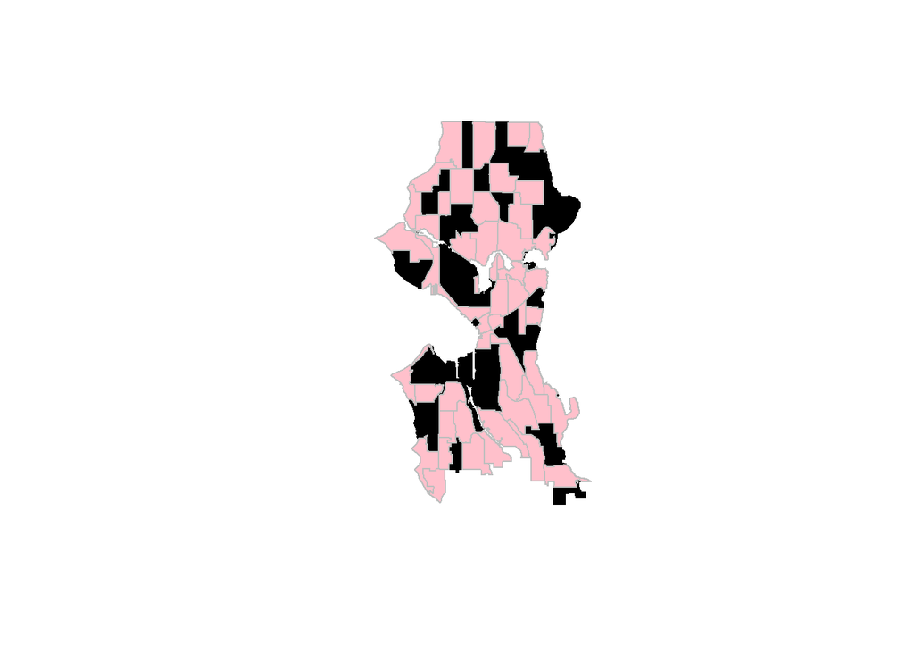

```r
plot(SeattleMap, col='black')
plot(MSeattleMap, col='pink',border='grey',add=T)
```

Due to problem in getting the suitable map for the data set, there are a lot of missing values in merged data set.

- Define the input

```r
library(RColorBrewer)
library(classInt)
varToPlot=MSeattleMap$Percent.of.Population.of.Color
varToPlot2=MSeattleMap$Percent.Bachelor.degree.or.higher
varToPlot3=MSeattleMap$Median.household.income..dollars.
```

- Get colors and intervals

```r
numberOfClasses = 3
colorForScale='YlGnBu'
colors = brewer.pal(numberOfClasses, colorForScale)
intervals <- classIntervals(varToPlot, numberOfClasses,
                            style = "quantile",
                            dataPrecision=2)
colorPallette <- findColours(intervals, colors)
```

- Plot variable1

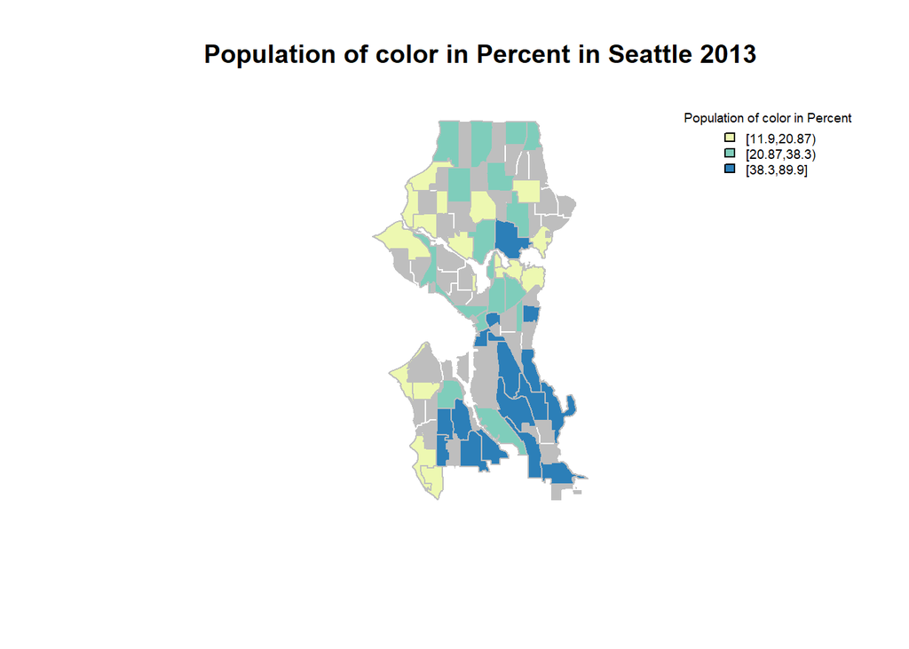

```r
legendText="Population of color in Percent"
shrinkLegend=0.6
title="Population of color in Percent in Seattle 2013"

plot(SeattleMap,col='grey',border='white',main=title)
plot(MSeattleMap, col = colorPallette,border='grey',add=T)

legend('topright', legend = names(attr(colorPallette, "table")),
       fill = attr(colorPallette, "palette"), cex = shrinkLegend,
       bty = "n",
       title=legendText)
```

Population of color are mainly distributed in the south part of Seattle.

- Plot variable2

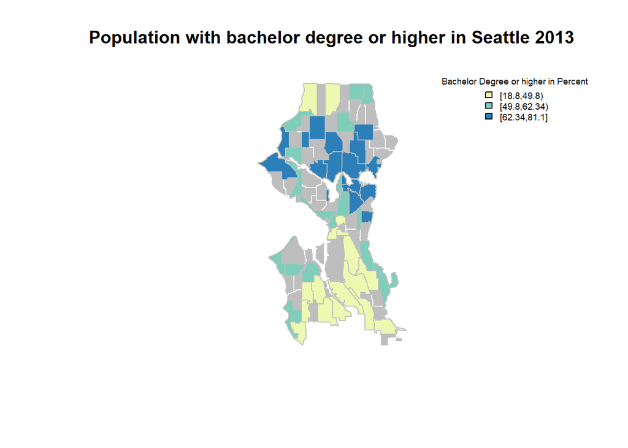

```r
numberOfClasses = 3
colorForScale='YlGnBu'
colors = brewer.pal(numberOfClasses, colorForScale)
intervals <- classIntervals(varToPlot2, numberOfClasses,
                            style = "quantile",
                            dataPrecision=2)
colorPallette <- findColours(intervals, colors)


legendText="Bachelor Degree or higher in Percent"
shrinkLegend=0.6
title="Population with bachelor degree or higher in Seattle 2013"

plot(SeattleMap,col='grey',border='white',main=title)
plot(MSeattleMap, col = colorPallette,border='grey',add=T)

legend('topright', legend = names(attr(colorPallette, "table")),
       fill = attr(colorPallette, "palette"), cex = shrinkLegend,
       bty = "n",
       title=legendText)
```

Communities in the north Seattle have higher ratio of residents holding bachelor degree or higher. Compared with last plot, south Seattle communities have much lower ratios of bachelor degree or higher residents.

- Plot variable3

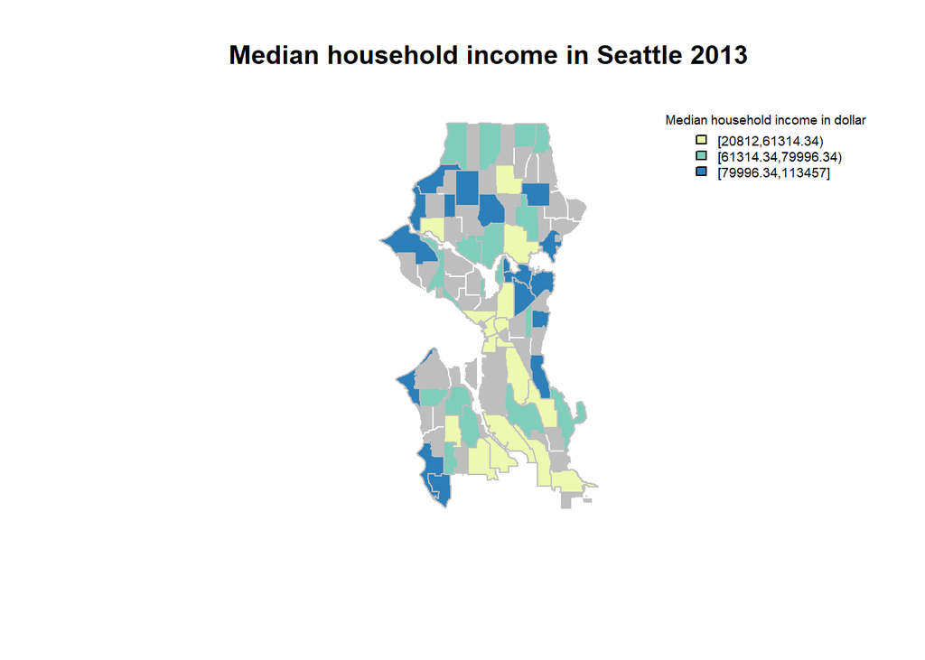

```r
numberOfClasses = 3
colorForScale='YlGnBu'
colors = brewer.pal(numberOfClasses, colorForScale)
intervals <- classIntervals(varToPlot3, numberOfClasses,
                            style = "quantile",
                            dataPrecision=2)
colorPallette <- findColours(intervals, colors)


legendText="Median household income in dollar"
shrinkLegend=0.6
title="Median household income in Seattle 2013"

plot(SeattleMap,col='grey',border='white',main=title)
plot(MSeattleMap, col = colorPallette,border='grey',add=T)

legend('topright', legend = names(attr(colorPallette, "table")),
       fill = attr(colorPallette, "palette"), cex = shrinkLegend,
       bty = "n",
       title=legendText)
```

The median household income roughly obey the trend showed in last two plots. Higher median household income communities appear more in north Seattle. South Seattle communities often have lower median household income.

## Recommendation

There are still large gaps between population of color and white. Population of color are more likely to hold lower degree and earn less money.

Thus, I recommend that city of Seattle shouold put more resources in improving the education equity and average salary for population of color.